# Trabajo Practico 4 - Metaanálisis

### Alumna: Martinez Gabriela

#### Consigna Nº1:

Para este ejercicio utilizaremos la base de datos que elaborá extrayendo los datos de los resúmenes que le fueron enviados. Evaluaremos la influencia de dos variables sobre el efecto de la intervención FLCD-15 sobre la ocurrencia de alegría. Para esto deberá realizar meta-análisis utilizando alegría como evento, con las siguientes especificaciones:

1. Realizar un análisis estratificado, dividiendo a los estudios que se realizaron antes de 2013 y los que se realizaron de 2013 en adelante.

**Metaanálisis estratificado**

```r
ma_estra_anio<-metabin(aleg_interv, N_interv,aleg_control, N_control, data=ma, studlab= paste(Estudio,"(", year, ")",sep = ""), subgroup = ifelse(year>2013,">2013","<2013"), fixed= F)
```

**Summary**

```r
summary(ma_estra_anio)
```

```
##                           RR           95%-CI %W(random) subgroup
## Iluso et al(2008)     1.4035 [0.9222; 2.1360]        9.6    <2013
## Cínico et al(2011)    1.2153 [0.7465; 1.9784]        9.3    <2013
## Payaso et al(2014)    4.0365 [2.9196; 5.5805]        9.9    >2013
## Curioso et al(2001)   7.3052 [6.0075; 8.8832]       10.3    <2013
## Honesto et al(2015)   1.0154 [0.8720; 1.1824]       10.4    >2013
## Cándido et al(2009)   3.1967 [2.7293; 3.7441]       10.3    <2013
## Random et al(2017)    1.1732 [0.8393; 1.6401]        9.9    >2013
## Patán et al(2016)     2.0525 [1.5729; 2.6782]       10.1    >2013
## Optimista et al(2017) 3.8916 [3.1066; 4.8750]       10.2    >2013
## Crédulo et al(2002)   6.0401 [4.3810; 8.3276]        9.9    <2013
##
## Number of studies combined: k = 10
## Number of observations: o = 4885
## Number of events: e = 1902
##
##                          RR           95%-CI    z  p-value
## Random effects model 2.5133 [1.6052; 3.9351] 4.03 < 0.0001
##
## Quantifying heterogeneity:
##  tau^2 = 0.4993 [0.2239; 1.7134]; tau = 0.7066 [0.4732; 1.3090]
##  I^2 = 97.4% [96.4%; 98.1%]; H = 6.22 [5.30; 7.31]
##
## Test of heterogeneity:
##       Q d.f.  p-value
##  348.31    9 < 0.0001
##
## Results for subgroups (random effects model):
##                    k     RR           95%-CI  tau^2    tau      Q   I^2
## subgroup = <2013   5 3.0504 [1.4992; 6.2066] 0.6272 0.7920  97.33 95.9%
## subgroup = >2013   5 2.0688 [1.1716; 3.6533] 0.4022 0.6342 129.80 96.9%
##
## Test for subgroup differences (random effects model):
##                     Q d.f. p-value
## Between groups   0.70    1  0.4029
##
## Details on meta-analytical method:
## - Mantel-Haenszel method
## - Restricted maximum-likelihood estimator for tau^2
## - Q-profile method for confidence interval of tau^2 and tau
```

**Forrest Plot**

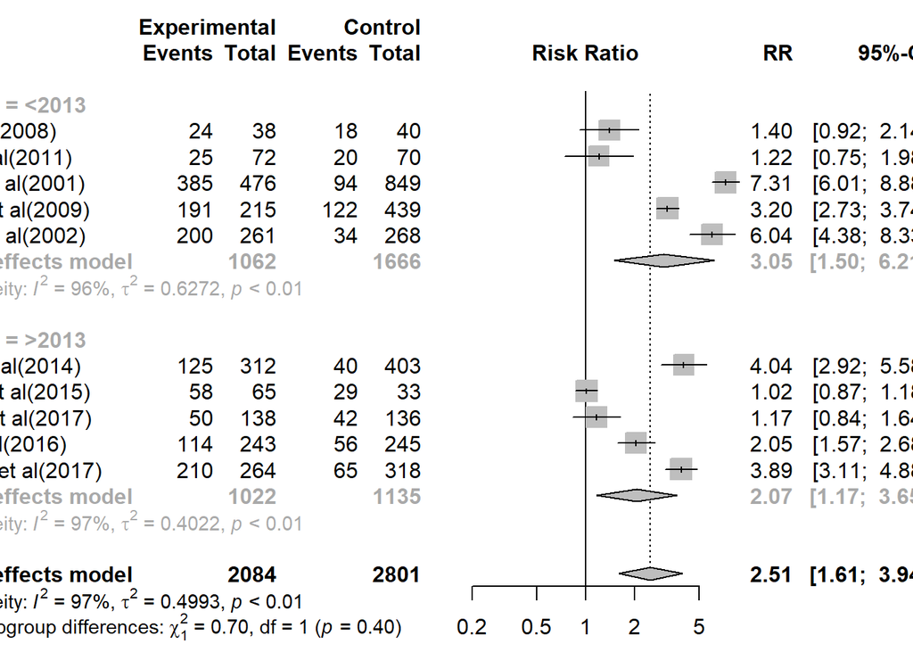

```r
forest(ma_estra_anio)
```

2. Realizar una metaregresión utilizando la variable “year” como regresora.

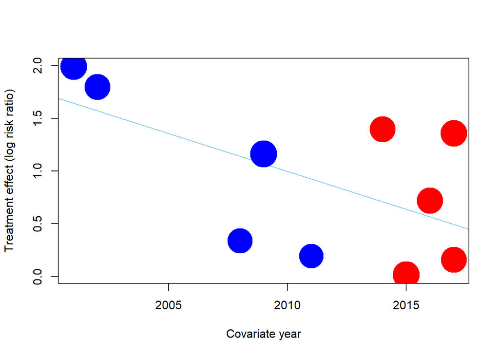

```r
mimeta<-metabin(aleg_interv, N_interv,aleg_control, N_control, data=ma, studlab= paste(Estudio,"(", year, ")",sep = ""),fixed= F)
regxyear<-metareg(mimeta, year)
bubble(regxyear, col = ifelse(ma$year>2013,"red","blue"), bg = ifelse(ma$year>2013,"red","blue"),  col.line = "skyblue")
```

3. Crear una variable que se llame “calidad” que indicará en una escala supuesta la calidad de los estudios. Los valores de esta variables deberán ser los siguientes:
- Iluso et al 8
- Cónico et al 9
- Payaso et al 4
- Curioso et al 2
- Honesto et al 6
- Cándido et al 7
- Random et al 10
- Patán et al 5
- Optimista et al 3
- Crédulo et al 1

```r
ma$calidad<-c(8,9,4,2,6,7,10,5,3,1)
```

4. Realizar una metaregresión con la variable calidad como regresora.

```r
reg2<-metareg(mimeta, calidad)
summary(reg2)
```

```
##
## Mixed-Effects Model (k = 10; tau^2 estimator: REML)
##
##   logLik  deviance       AIC       BIC      AICc
##  -4.2045    8.4090   14.4090   14.6473   20.4090
##
## tau^2 (estimated amount of residual heterogeneity):     0.1581 (SE = 0.0901)
## tau (square root of estimated tau^2 value):             0.3976
## I^2 (residual heterogeneity / unaccounted variability): 91.06%
## H^2 (unaccounted variability / sampling variability):   11.18
## R^2 (amount of heterogeneity accounted for):            68.34%
##
## Test for Residual Heterogeneity:
## QE(df = 8) = 171.7021, p-val < .0001
##
## Test of Moderators (coefficient 2):
## QM(df = 1) = 18.6374, p-val < .0001
##
## Model Results:
##
##          estimate      se     zval    pval    ci.lb    ci.ub
## intrcpt    2.0420  0.2895   7.0534  <.0001   1.4746   2.6094  ***
## calidad   -0.2055  0.0476  -4.3171  <.0001  -0.2988  -0.1122  ***
##
## ---
## Signif. codes:  0 '***' 0.001 '**' 0.01 '*' 0.05 '.' 0.1 ' ' 1
```

5. Realizar un Bubble plot con la variable “calidad” como regresora y cambiar el color de las burbujas.

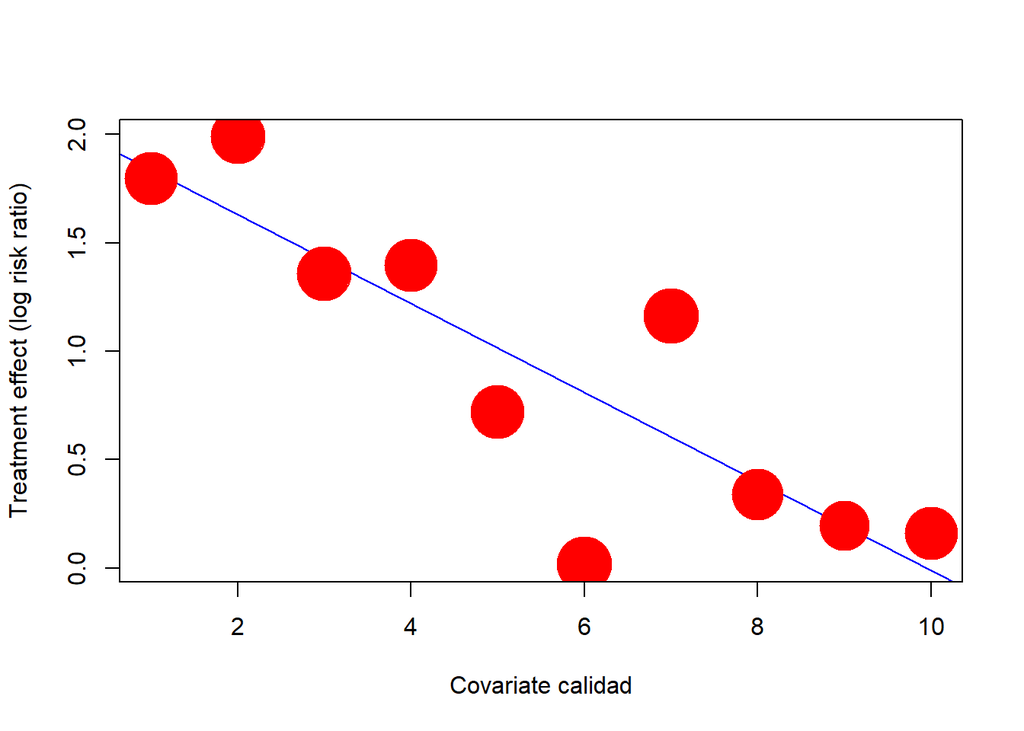

```r
bubble(reg2, col = "red", bg = "red",  col.line = "blue")
```

6. Realizar una metaregresión con las variables “year” y “calidad” como regresoras.

```r
reg3<-metareg(mimeta, year+calidad)
summary(reg3)
```

```
##
## Mixed-Effects Model (k = 10; tau^2 estimator: REML)
##
##   logLik  deviance       AIC       BIC      AICc
##  -3.3498    6.6996   14.6996   14.4833   34.6996
##
## tau^2 (estimated amount of residual heterogeneity):     0.1394 (SE = 0.0865)
## tau (square root of estimated tau^2 value):             0.3734
## I^2 (residual heterogeneity / unaccounted variability): 89.39%
## H^2 (unaccounted variability / sampling variability):   9.43
## R^2 (amount of heterogeneity accounted for):            72.08%
##
## Test for Residual Heterogeneity:
## QE(df = 7) = 107.1906, p-val < .0001
##
## Test of Moderators (coefficients 2:3):
## QM(df = 2) = 22.5019, p-val < .0001
##
## Model Results:
##
##          estimate       se     zval    pval     ci.lb     ci.ub
## intrcpt   68.9019  50.2774   1.3704  0.1706  -29.6400  167.4437
## year      -0.0333   0.0251  -1.3298  0.1836   -0.0824    0.0158
## calidad   -0.1750   0.0507  -3.4550  0.0006   -0.2743   -0.0757  ***
##
## ---
## Signif. codes:  0 '***' 0.001 '**' 0.01 '*' 0.05 '.' 0.1 ' ' 1
```

#### Consigna Nº2:

En la base de datos “atc_mv” que se le entregá para la actividad de clase se encuentran los datos un meta-análisis de datos observacionales sobre los efectos de la angioplastia de múltiples vasos en comparación con la angioplastia del vaso culpable en pacientes con síndromes coronarios agudos sin elevación del ST (abrir la arteria responsable del cuadro clínico o abrir todas las arterias que tienen obstrucciones en la angiografía coronaria). Con estos datos:

1. Realice un meta-análisis de los estimadores ajustados, utilizando como evento (punto final) “muerte_iam” (que indica la ocurrencia del punto final combinado muerte o re-infarto).

**Metaanálisis y summary**

```r
atc_mv$se_muerte<-(log(atc_mv$uci_muerte)-log(atc_mv$rr_muerte))/1.96

ma1<-metagen(log(rr_muerte), se_muerte, data= atc_mv, studlab= paste(Nombre,"(", Year, ")",sep = ""), sm= "HR", fixed= T)
summary(ma1)
```

```
##                             HR           95%-CI %W(common) %W(random)
## Kim et al.(2010)            NA                         0.0        0.0
## Lee et al.(2011)        0.6900 [0.2467; 1.9300]        1.3        6.9
## Mariani et al.(2001)        NA                         0.0        0.0
## Onuma et al.(2013)      0.5500 [0.3781; 0.8000]        9.6       21.6
## Palmer et al.(2004)         NA                         0.0        0.0
## Shishehbor et al.(2007) 0.9400 [0.6644; 1.3300]       11.2       22.7
## Zapata et al.(2009)         NA                         0.0        0.0
## Brener et al.(2002)         NA                         0.0        0.0
## Hassanin et al.(2014)       NA                         0.0        0.0
## Shishehbor et al.(2006) 0.7500 [0.3125; 1.8000]        1.8        8.9
## Brener et al.(2008)     1.1100 [0.9702; 1.2700]       74.2       30.1
## Bauer et al.(2011)      0.5400 [0.2390; 1.2200]        2.0        9.8
##
## Number of studies combined: k = 6
##
##                          HR           95%-CI     z p-value
## Common effect model  0.9910 [0.8825; 1.1129] -0.15  0.8789
## Random effects model 0.7997 [0.5888; 1.0863] -1.43  0.1527
##
## Quantifying heterogeneity:
##  tau^2 = 0.0764 [0.0035; 0.4458]; tau = 0.2763 [0.0595; 0.6677]
##  I^2 = 67.3% [22.3%; 86.2%]; H = 1.75 [1.13; 2.70]
##
## Test of heterogeneity:
##      Q d.f. p-value
##  15.30    5  0.0092
##
## Details on meta-analytical method:
## - Inverse variance method
## - Restricted maximum-likelihood estimator for tau^2
## - Q-profile method for confidence interval of tau^2 and tau
```

**Forrest Plot**

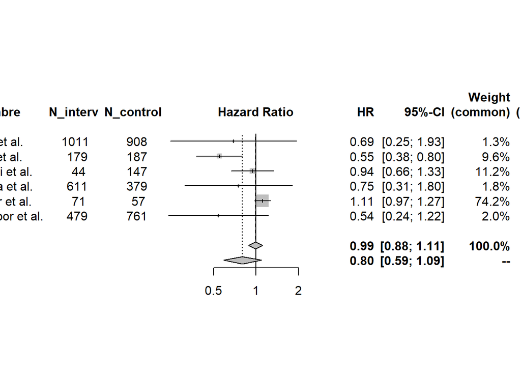

```r
forest(ma1, allstudies = F, leftcols = c("Nombre","N_interv","N_control"),comb.fixed= T)
```

b. Cuantos estudios ingresan en el análisis (es decir que reportaron los estimadores del efecto ajustados).  
**Ingresaron 6 estudios**  
c. Cuantos pacientes aportan datos para este análisis en cada grupo?  
**en el grupo interv: 2395**  
**en el grupo control: 2439**  
d. Cuantos pacientes hubieran aportado datos en caso de que TODOS los estudios hubieran reportado este estimador ajustado?

```r
sum(atc_mv$N_control,atc_mv$N_interv)
```

```
## [1] 117685
```

5. Realice un funnel plot del meta-análisis con estimadores ajustados.

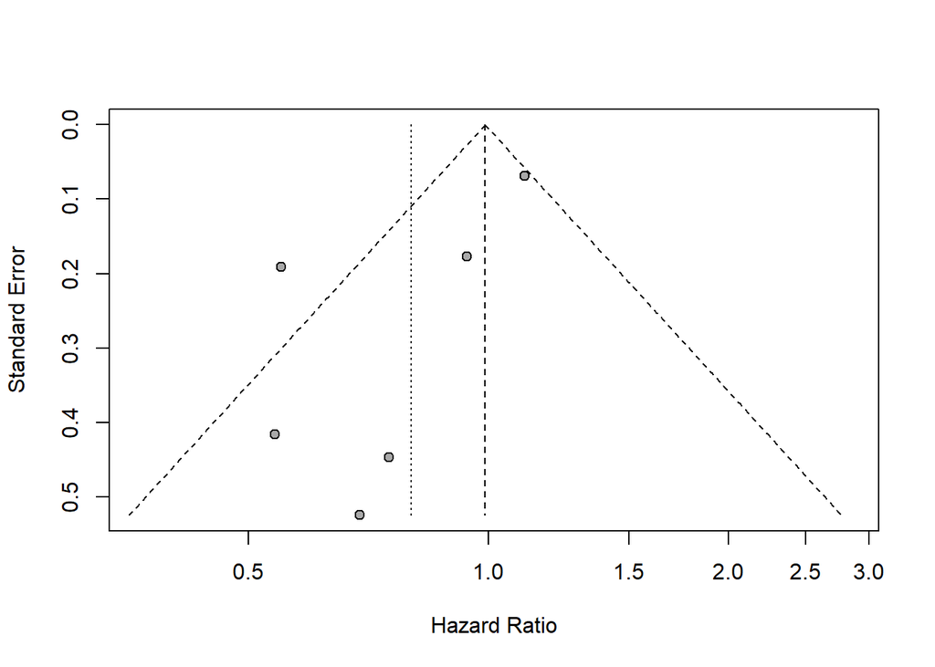

```r
funnel(ma1)
```

#### Consigna Nº3:

Con la base de datos “vni_eap” que utilizamos en la actividad práctica realice un meta-análisis en red, con los siguientes eventos: a. “muerte” b. “po2” (presión parcial de oxígeno a la hora del comienzo del tratamiento“). c. En ambos casos utilice el”Control" como grupo de referencia. d. Realice un forest plot que resuma toda la evidencia disponible y un forest plot que diferencie la evidencia directa de la indirecta.

```r
eap<-eap[-c(42:44), ]
p<-pairwise(tratamiento, Muerte, n, data= eap, studlab= paste(autor,"(", year, ")",sep = ""))
p
```

```
##                         studlab treat1  treat2           TE      seTE event1
## 1          Bellone et al.(2004)  BiPAP    CPAP -1.694595721 1.5214267      0
## 2          Ferrari et al.(2007)  BiPAP    CPAP  0.482426149 0.8696530      3
## 3            Liesching, K(2003)  BiPAP    CPAP           NA        NA      0
## 4          Zhang Xiao-qin(2005)  BiPAP    CPAP           NA        NA      0
## 5              Wang Houli(2003)  BiPAP    CPAP           NA        NA      0
## 6      Rusterholtz et al.(2008)  BiPAP    CPAP  0.111225635 0.6233337      4
## 7               Ferrari G(2010)  BiPAP    CPAP  1.252762968 0.7699722      7
## 8                Nouira S(2010)  BiPAP    CPAP  0.530826290 0.7164714      5
## 9            Fontanella B(2009)  BiPAP    CPAP  0.100083459 1.3783140      1
## 10          Moritz et al.(2007)  BiPAP    CPAP -0.527632742 0.5814214      4
## 11 Martin-Bermudez et al.(2002)  BiPAP    CPAP -0.966301152 0.8062064      2
## 12           Cross et al.(2003)  BiPAP    CPAP -0.482654747 0.6906404      3
## 13           Mehta et al.(1997)  BiPAP    CPAP -0.767255153 1.1626041      1
## 14         Bellone et al.(2005)  BiPAP    CPAP -1.098612289 1.5995495      0
```

[output cut: 153 more lines]

```r
ma_red<-netmeta(p)
```

```
## Comparisons not considered in network meta-analysis:
##               studlab treat1  treat2 TE seTE
##    Liesching, K(2003)  BiPAP    CPAP NA   NA
##  Zhang Xiao-qin(2005)  BiPAP    CPAP NA   NA
##      Wang Houli(2003)  BiPAP    CPAP NA   NA
##    Hao,Chao-xia(2002)   CPAP Control NA   NA
##   Moritz et al.(2003)   CPAP Control NA   NA
```

```r
summary(ma_red)
```

```
## Original data (with adjusted standard errors for multi-arm studies):
##
##                               treat1  treat2      TE   seTE seTE.adj.f
## Bellone et al.(2004)           BiPAP    CPAP -1.6946 1.5214     1.5214
## Ferrari et al.(2007)           BiPAP    CPAP  0.4824 0.8697     0.8697
## Rusterholtz et al.(2008)       BiPAP    CPAP  0.1112 0.6233     0.6233
## Ferrari G(2010)                BiPAP    CPAP  1.2528 0.7700     0.7700
## Nouira S(2010)                 BiPAP    CPAP  0.5308 0.7165     0.7165
## Fontanella B(2009)             BiPAP    CPAP  0.1001 1.3783     1.3783
## Moritz et al.(2007)            BiPAP    CPAP -0.5276 0.5814     0.5814
## Martin-Bermudez et al.(2002)   BiPAP    CPAP -0.9663 0.8062     0.8062
## Cross et al.(2003)             BiPAP    CPAP -0.4827 0.6906     0.6906
## Mehta et al.(1997)             BiPAP    CPAP -0.7673 1.1626     1.1626
## Bellone et al.(2005)           BiPAP    CPAP -1.0986 1.5995     1.5995
## Levitt et al.(2001)            BiPAP Control -0.2113 0.7485     0.7485
## Ye Fei(2007)                   BiPAP Control -1.4424 1.0564     1.0564
## Masip y et al.(2000)           BiPAP Control -1.6621 1.5148     1.5148
## Nava et al.(2003)              BiPAP Control -0.4055 0.4970     0.4970
## Ferrer et al.(2003)            BiPAP Control -0.6931 1.1690     1.1690
## Park et al.(2004)              BiPAP Control -1.1364 0.7689     0.8080
## Park et al.(2004)              BiPAP    CPAP  0.6931 1.1941     2.2143
## Park et al.(2004)            Control    CPAP  1.8295 1.0446     1.1653
## Crane et al.(2004)             BiPAP Control -0.1671 0.4880     0.4952
## Crane et al.(2004)             BiPAP    CPAP  2.3979 1.4437     2.1342
## Crane et al.(2004)           Control    CPAP  2.5649 1.4340     1.8966
## Zhang De-yong(2005)            BiPAP Control -0.1671 0.4880     0.4952
## Zhang De-yong(2005)            BiPAP    CPAP  2.3979 1.4437     2.1342
## Zhang De-yong(2005)          Control    CPAP  2.5649 1.4340     1.8966
## Gray A(2008)                   BiPAP Control -0.0267 0.2273     0.2756
## Gray A(2008)                   BiPAP    CPAP  0.0014 0.2324     0.2883
## Gray A(2008)                 Control    CPAP  0.0281 0.2291     0.2798
## Delclaux et al.(2000)        Control    CPAP  0.0953 0.4362     0.4362
## Kelly et al.(2002)           Control    CPAP  1.1146 0.7573     0.7573
## Lin et al.(1995)             Control    CPAP  0.4055 0.6137     0.6137
## L'Her et al.(2004)           Control    CPAP  0.0867 0.3313     0.3313
## Rassmunssen et al.(1985)     Control    CPAP  0.6931 0.6325     0.6325
## Bersten et al.(1991)         Control    CPAP  0.6419 0.8046     0.8046
## Takeda et al.(1997)          Control    CPAP  1.0986 1.0954     1.0954
## Takeda et al.(1998)          Control    CPAP  1.9459 0.9803     0.9803
##                              seTE.adj.r narms multiarm
```

[output cut: 200 more lines]

```
##
## Treatment estimate (sm = 'RR', comparison: other treatments vs 'BiPAP'):
##             RR           95%-CI     z p-value
## BiPAP        .                .     .       .
## Control 1.3404 [1.0080; 1.7824]  2.01  0.0439
## CPAP    0.9809 [0.7348; 1.3095] -0.13  0.8961
##
## Quantifying heterogeneity / inconsistency:
## tau^2 = 0; tau = 0; I^2 = 0% [0.0%; 40.2%]
##
## Tests of heterogeneity (within designs) and inconsistency (between designs):
##                     Q d.f. p-value
## Total           26.65   30  0.6417
## Within designs  24.93   27  0.5785
## Between designs  1.72    3  0.6322
```

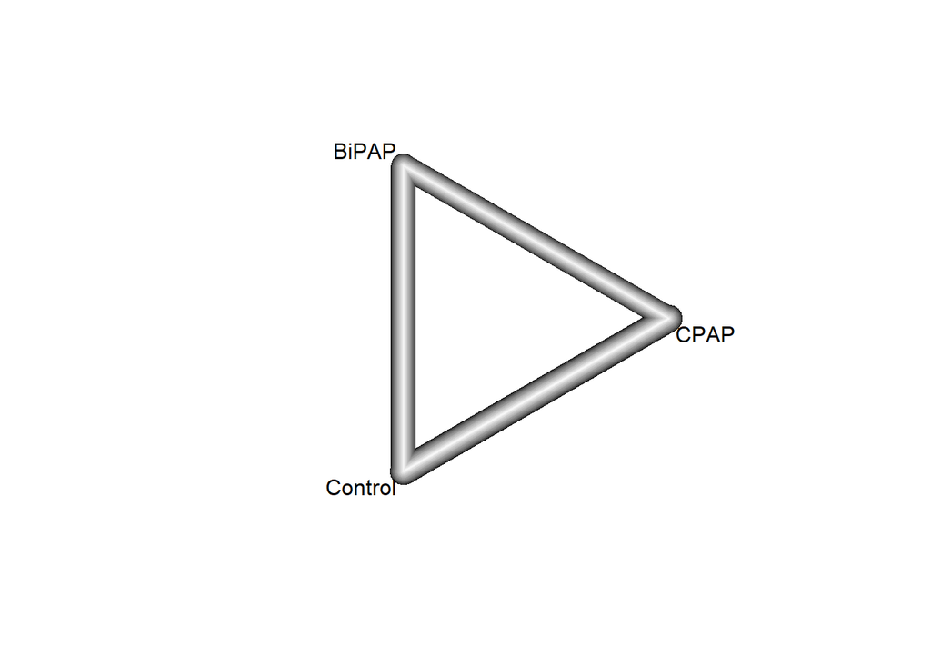

```r
netgraph(ma_red)
```

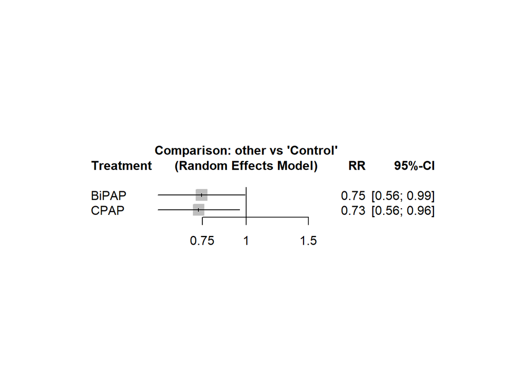

```r
forest(ma_red, reference.group= "Control", drop.reference.group = T)
```

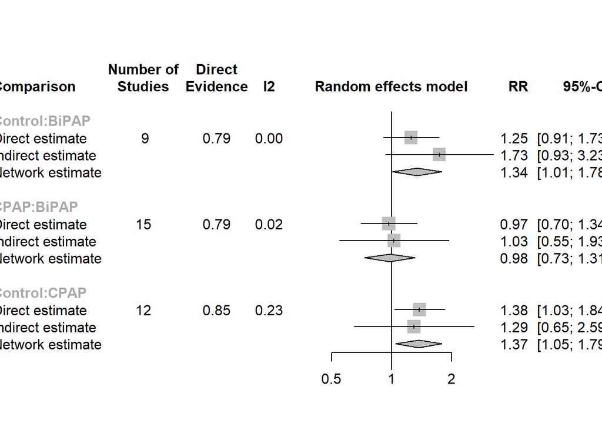

```r
ns<-netsplit(ma_red)
forest(ns)
```

```r
p2<-pairwise(tratamiento, mean= po2, n= n, sd=ds_po2, data= eap, studlab= paste(autor,"(", year, ")",sep = ""))
ma_red2<-netmeta(p2)
```

```
## Comparisons not considered in network meta-analysis:
##                       studlab treat1  treat2 TE seTE
##          Bellone et al.(2004)  BiPAP    CPAP NA   NA
##          Ferrari et al.(2007)  BiPAP    CPAP NA   NA
##            Liesching, K(2003)  BiPAP    CPAP NA   NA
##              Wang Houli(2003)  BiPAP    CPAP NA   NA
##               Ferrari G(2010)  BiPAP    CPAP NA   NA
##            Fontanella B(2009)  BiPAP    CPAP NA   NA
##           Moritz et al.(2007)  BiPAP    CPAP NA   NA
##  Martin-Bermudez et al.(2002)  BiPAP    CPAP NA   NA
##            Cross et al.(2003)  BiPAP    CPAP NA   NA
##          Bellone et al.(2005)  BiPAP    CPAP NA   NA
##          Masip y et al.(2000)  BiPAP Control NA   NA
##             Nava et al.(2003)  BiPAP Control NA   NA
##           Ferrer et al.(2003)  BiPAP Control NA   NA
##             Park et al.(2004)  BiPAP Control NA   NA
##             Park et al.(2004)  BiPAP    CPAP NA   NA
##             Park et al.(2004)   CPAP Control NA   NA
##           Zhang De-yong(2005)  BiPAP Control NA   NA
##           Zhang De-yong(2005)  BiPAP    CPAP NA   NA
##           Zhang De-yong(2005)   CPAP Control NA   NA
##         Delclaux et al.(2000)   CPAP Control NA   NA
##            Kelly et al.(2002)   CPAP Control  3   NA
##            L'Her et al.(2004)   CPAP Control NA   NA
##          Bersten et al.(1991)   CPAP Control NA   NA
##           Moritz et al.(2003)   CPAP Control NA   NA
##           Takeda et al.(1997)   CPAP Control NA   NA
##           Takeda et al.(1998)   CPAP Control NA   NA
```

```r
summary(ma_red2)
```

```
## Original data (with adjusted standard errors for multi-arm studies):
##
##                           treat1  treat2       TE    seTE seTE.adj.f seTE.adj.r
## Zhang Xiao-qin(2005)       BiPAP    CPAP   6.9000  0.7868     0.7868    13.5509
## Rusterholtz et al.(2008)   BiPAP    CPAP   7.0000 11.3210    11.3210    17.6401
## Nouira S(2010)             BiPAP    CPAP   5.0900  2.0113     2.0113    13.6767
## Mehta et al.(1997)         BiPAP    CPAP   2.0000 19.2638    19.2638    23.5393
## Levitt et al.(2001)        BiPAP Control  25.0000 36.0471    36.0471    38.5020
## Ye Fei(2007)               BiPAP Control  27.1000  3.4425     3.4425    13.9592
## Crane et al.(2004)         BiPAP Control -12.3000 11.1923    19.0375    22.9814
## Crane et al.(2004)         BiPAP    CPAP  16.3000  8.5340     9.2878    18.8519
## Crane et al.(2004)       Control    CPAP  28.6000  9.2304    10.2553    19.6243
## Gray A(2008)               BiPAP Control  -3.7000  5.1648     6.6412    17.8326
## Gray A(2008)               BiPAP    CPAP   9.1000  5.0471     6.2724    17.7280
## Gray A(2008)             Control    CPAP  12.8000  4.5881     5.3059    17.3579
## Hao,Chao-xia(2002)       Control    CPAP -47.9000  3.8747     3.8747    14.0720
## Lin et al.(1995)         Control    CPAP -85.0000 15.1822    15.1822    20.3349
## Rassmunssen et al.(1985) Control    CPAP -13.0000  3.1064     3.1064    13.8801
##                          narms multiarm
## Zhang Xiao-qin(2005)         2
## Rusterholtz et al.(2008)     2
## Nouira S(2010)               2
## Mehta et al.(1997)           2
## Levitt et al.(2001)          2
## Ye Fei(2007)                 2
## Crane et al.(2004)           3        *
## Crane et al.(2004)           3        *
## Crane et al.(2004)           3        *
## Gray A(2008)                 3        *
## Gray A(2008)                 3        *
## Gray A(2008)                 3        *
## Hao,Chao-xia(2002)           2
## Lin et al.(1995)             2
## Rassmunssen et al.(1985)     2
##
## Number of treatment arms (by study):
##                          narms
## Zhang Xiao-qin(2005)         2
## Rusterholtz et al.(2008)     2
## Nouira S(2010)               2
```

[output cut: 78 more lines]

```
##
## Treatment estimate (sm = 'MD', comparison: other treatments vs 'BiPAP'):
##               MD              95%-CI     z p-value
## BiPAP          .                   .     .       .
## Control -19.7492 [-33.3147; -6.1837] -2.85  0.0043
## CPAP     -3.3274 [-14.9062;  8.2514] -0.56  0.5733
##
## Quantifying heterogeneity / inconsistency:
## tau^2 = 183.0074; tau = 13.5280; I^2 = 93.1% [89.8%; 95.4%]
##
## Tests of heterogeneity (within designs) and inconsistency (between designs):
##                      Q d.f.  p-value
## Total           160.12   11 < 0.0001
## Within designs   67.02    8 < 0.0001
## Between designs  93.10    3 < 0.0001
```

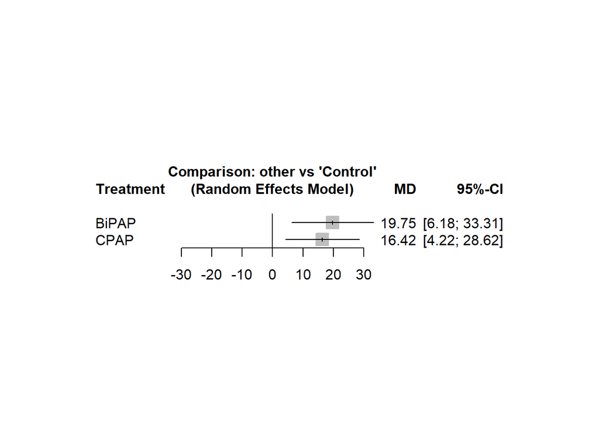

```r
forest(ma_red2, reference.group= "Control", drop.reference.group = T)
```

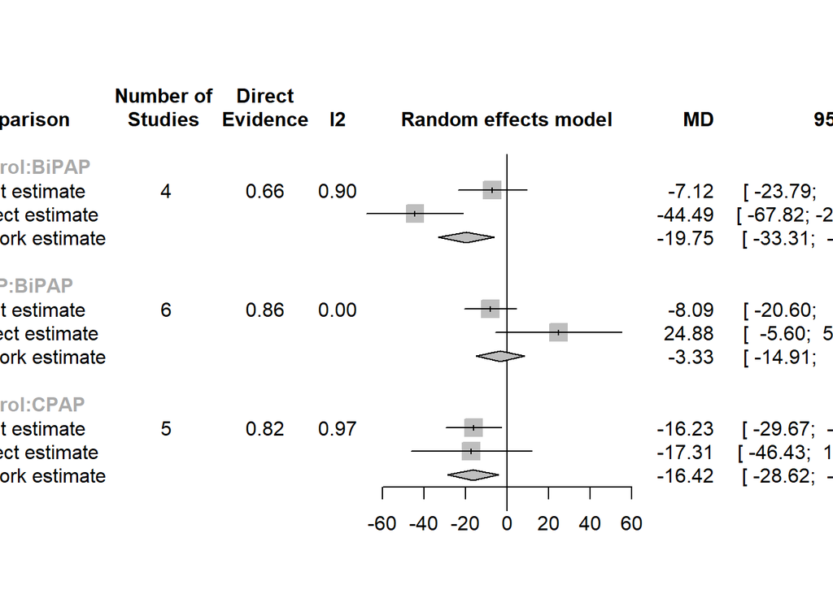

```r
ns2<-netsplit(ma_red2)
forest(ns2)
```

#### Consigna Nº4:

La base de datos “ejercicio_MA_red” contiene los datos de un meta-análisis de diversas drogas en distintas dosis para un forma de epilepsia. Con estos datos:  
a. Realice un meta-análisis en red utilizando “evento1” como evento. b. Realice el gráfico que muestra la red de evidencia. c. Realice un forest plot que resuma la evidencia directa e indirecta por separado. d. Realice un ranking de los tratamientos.

```r
p3<-pairwise(tratamiento,evento1, reference.group = "Placebo", n= aleatorizados, data= MA_red, studlab= paste(Autor,"(", Year, ")",sep = ""))
ma_red3<-netmeta(p3)
summary(ma_red3)
```

```
## Original data (with adjusted standard errors for multi-arm studies):
##
##                     treat1  treat2      TE   seTE seTE.adj.f seTE.adj.r narms
## Ben Menachem(2007)  LCM200  LCM400 -0.2195 0.1808     0.2506     0.2506     4
## Ben Menachem(2007)  LCM200  LCM600 -0.3459 0.1738     0.2262     0.2262     4
## Ben Menachem(2007)  LCM200 Placebo  0.4615 0.2427     0.4302     0.4302     4
## Ben Menachem(2007)  LCM400  LCM600 -0.1263 0.1563     0.1894     0.1894     4
## Ben Menachem(2007)  LCM400 Placebo  0.6810 0.2306     0.3601     0.3601     4
## Ben Menachem(2007)  LCM600 Placebo  0.8074 0.2251     0.3251     0.3251     4
## Chung(2007)         LCM400  LCM600 -0.2968 0.1331     0.1397     0.1397     3
## Chung(2007)         LCM400 Placebo  0.7405 0.2259     0.2943     0.2943     3
## Chung(2007)         LCM600 Placebo  1.0373 0.2296     0.3236     0.3236     3
## Halasz(2007)        LCM200  LCM400 -0.4180 0.1706     0.1944     0.1944     3
## Halasz(2007)        LCM200 Placebo  0.1273 0.2026     0.2854     0.2854     3
## Halasz(2007)        LCM400 Placebo  0.5453 0.1806     0.2119     0.2119     3
## Shorvon(2000)      LVT1000 LVT2000 -0.5199 0.2315     0.2416     0.2416     3
## Shorvon(2000)      LVT1000 Placebo  1.1912 0.4122     0.6663     0.6663     3
## Shorvon(2000)      LVT2000 Placebo  1.7111 0.3892     0.4656     0.4656     3
## Cereghino(2000)    LVT1000 LVT3000 -0.0810 0.2015     0.2126     0.2126     3
## Cereghino(2000)    LVT1000 Placebo  1.1106 0.3338     0.4654     0.4654     3
## Cereghino(2000)    LVT3000 Placebo  1.1915 0.3289     0.4292     0.4292     3
## BenMenachem(2000)  LVT3000 Placebo  0.8989 0.2401     0.2401     0.2401     2
## Ryvlin(2014)        BVC100   BVC20  0.2776 0.2115     0.2729     0.2729     4
## Ryvlin(2014)         BVC20   BVC50  0.0000 0.2321     0.3359     0.3359     4
## Ryvlin(2014)         BVC20 Placebo  0.3102 0.2587     0.4093     0.4093     4
## Ryvlin(2014)        BVC100   BVC50  0.2776 0.2115     0.2729     0.2729     4
## Ryvlin(2014)         BVC50 Placebo  0.3102 0.2587     0.4093     0.4093     4
## Ryvlin(2014)        BVC100 Placebo  0.5878 0.2404     0.3325     0.3325     4
## Biton(2015)          BVC20    BVC5  0.0602 0.2657     0.3941     0.3941     4
## Biton(2015)           BVC5   BVC50 -0.4012 0.2400     0.3081     0.3081     4
## Biton(2015)           BVC5 Placebo  0.2719 0.2988     0.4922     0.4922     4
## Biton(2015)          BVC20   BVC50 -0.3410 0.2319     0.2918     0.2918     4
## Biton(2015)          BVC20 Placebo  0.3321 0.2923     0.4663     0.4663     4
## Biton(2015)          BVC50 Placebo  0.6731 0.2692     0.3645     0.3645     4
## Klein(2014)         BVC100  BVC200  0.0297 0.1134     0.1257     0.1257     3
## Klein(2014)         BVC100 Placebo  0.5870 0.1422     0.1828     0.1828     3
## Klein(2014)         BVC200 Placebo  0.5573 0.1436     0.1884     0.1884     3
## French(2012)       Placebo    PMP8 -0.3517 0.1883     0.2388     0.2388     3
## French(2012)         PMP12    PMP8 -0.0408 0.1606     0.1817     0.1817     3
## French(2012)       Placebo   PMP12 -0.3109 0.1905     0.2466     0.2466     3
```

[output cut: 366 more lines]

```
## Placebo      .                .    .        .
## PMP12   1.7255 [1.3223; 2.2517] 4.02 < 0.0001
## PMP2    1.0801 [0.7460; 1.5639] 0.41   0.6832
## PMP4    1.4970 [1.0735; 2.0875] 2.38   0.0174
## PMP8    1.7826 [1.4180; 2.2409] 4.95 < 0.0001
## ZNZ400  1.7004 [1.1935; 2.4225] 2.94   0.0033
##
## Quantifying heterogeneity / inconsistency:
## tau^2 = 0; tau = 0; I^2 = 0% [0.0%; 45.4%]
##
## Tests of heterogeneity (within designs) and inconsistency (between designs):
##                     Q d.f. p-value
## Total           17.78   22  0.7192
## Within designs   6.94    7  0.4354
## Between designs 10.84   15  0.7639
```

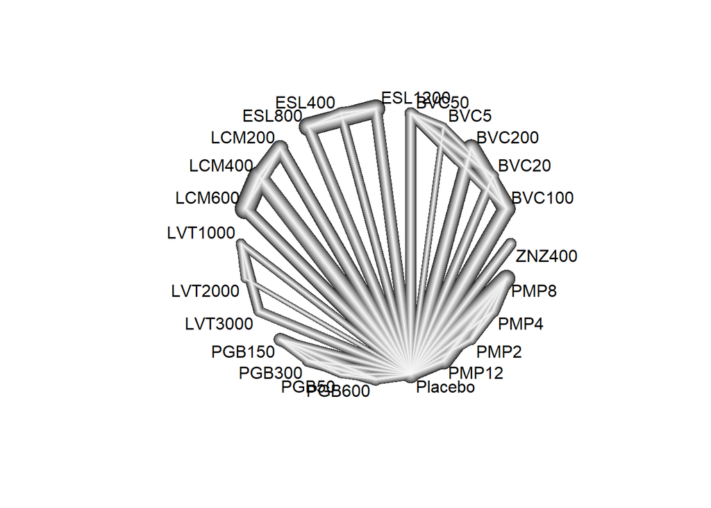

```r
netgraph(ma_red3)
```

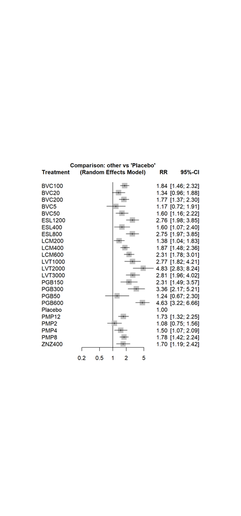

```r
forest(ma_red3)
```

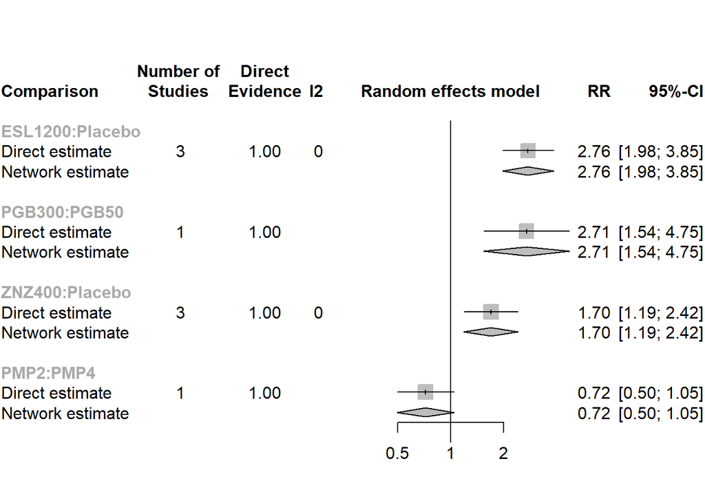

```r
ns3<-netsplit(ma_red3)
forest(ns3, show="direct.only", direct=TRUE, indirect= F)
```

```r
forest(ns3, show="indirect.only", direct=F, indirect= T)
```

[figure not shown]

```r
netrank(ma_red3)
```

```
##         P-score (fixed) P-score (random)
## Placebo          0.9595           0.9595
## PMP2             0.9116           0.9116
## BVC5             0.8579           0.8579
## PGB50            0.8030           0.8030
## BVC20            0.7912           0.7912
## LCM200           0.7741           0.7741
## PMP4             0.7027           0.7027
## ESL400           0.6394           0.6394
## BVC50            0.6383           0.6383
## ZNZ400           0.5851           0.5851
## PMP12            0.5718           0.5718
## BVC200           0.5444           0.5444
## PMP8             0.5339           0.5339
## BVC100           0.5011           0.5011
## LCM400           0.4955           0.4955
## PGB150           0.3369           0.3369
## LCM600           0.3107           0.3107
## LVT1000          0.2211           0.2211
## ESL800           0.2132           0.2132
## ESL1200          0.2110           0.2110
## LVT3000          0.2055           0.2055
## PGB300           0.1305           0.1305
## LVT2000          0.0323           0.0323
## PGB600           0.0293           0.0293
```